# IoT prediction

Borys Sobiegraj

1 Jan 2016

# Executive summary

The presented analysis takes on the question of classifying the manner in which 6 participants performed barbell lifts correctly and incorrectly in 5 different ways. The variable which differentiates the manner in which they performed the exercises is the “classe” variable which besides which we have 159 other variables at our disposal to build the model for prediction.

# Data preperation and exploration

## Import and dataset slicing

Both datasets that were to be used were downloaded (manually) and imported into the R script:

```r
folder <- "D:\\Users\\bsobiegraj001\\Desktop\\Prediction\\"

testing_set <- read.csv(paste0(folder, "pml-testing.csv"),na.strings = "#DIV/0!")
training_set <- read.csv(paste0(folder, "pml-training.csv"),na.strings = "#DIV/0!")
```

As the main goal of the “testing_set” is evaluation of work performed is being a validation set for the overall effort it won?t be used until the very end of the excersise. As for the “training_set” it will be divided into two sets:

1. Train - for learning of the models and by extension evaluating in sample error
2. Test - for testing models and evaluating out of sample error

```r
# dividing set for validation - 70% of the sample will be used in to train
inTraining <- createDataPartition(training_set$classe, times = 1, p = 0.7, list = F)
Train <- training_set[inTraining,]
Test <- training_set[-inTraining,]
```

## Data exploration and adjustments

Having divided the dataset into training and testing part I am using training for further exploration and adjustments. I start by getting a more in depth understanding of the dataset:

- Basic checks

```r
head(Train)
names(Train)
dim(Train)
```

- Advanced checks

```r
# deeper look into data
str(Train)
summary(Train)
```

```r
## How many columns of each type are there
table(sapply(Train, class))
```

```
##
##  factor integer logical numeric
##      71      29       6      54
```

Given what we found it is worth dividing further analysis of data into subgroups related to types of variables we have in the dataset.

```r
numeric_columns <- Train[,sapply(Train, class) == "numeric"]
logical_columns <- Train[,sapply(Train, class) == "logical"]
integer_columns <- Train[,sapply(Train, class) == "integer"]
factor_columns <- Train[,sapply(Train, class) == "factor"]
```

The assumed flow of the analysis will be checking:

1. summary information concerning the features so we know what we are dealing with
2. level of variability
3. percentage of null/NA values per feature
4. exploratory charts
5. defining Data frame containing the final variables subset for modeling purposes

## Feature selection

The mention flow was applied with different results to all 4 groups: factor, integer, logical, numeric.

### numeric variables

Firstly we want to understand if some of the metrics by their definition (like being metadata which should not be used) are to be excluded:

```r
summary(numeric_columns)
```

Given the 54 coumns we start by checking the variance in the data set:

```r
NumericNZV <- nearZeroVar(numeric_columns, saveMetrics = TRUE)
NumericNZV_TRUE <- rownames(NumericNZV[NumericNZV$nzv==TRUE,])
```

Having reviewed the results I subseted the dataset:

```r
NumericNZV_Final <- numeric_columns[, - which(names(numeric_columns) %in% NumericNZV_TRUE)]
```

Next I checked the amount of null values per feautes and given the maximum 20% NA’s threshold I subseted the dataset:

```r
Numeric_NA_freq <- apply(is.na(NumericNZV_Final), 2, sum)/ dim(NumericNZV_Final)[1]
Numeric_NotEmptyFeatures <- names(Numeric_NA_freq[Numeric_NA_freq < 0.2])
Numeric_NotNA <- NumericNZV_Final[,Numeric_NotEmptyFeatures]
```

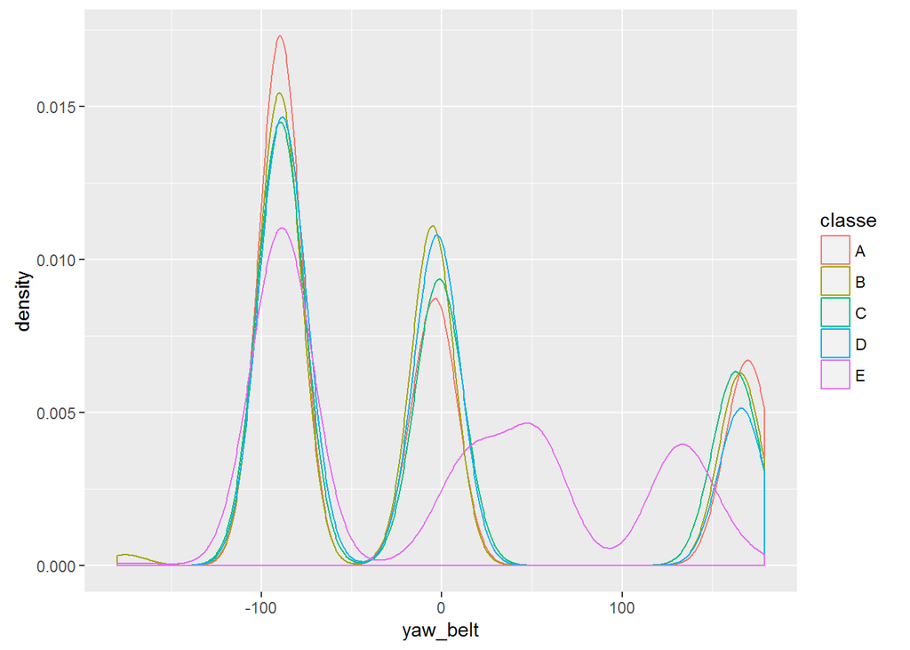

```r
DataForPloting <- cbind(NumericNZV_Final,Train$classe)
names(DataForPloting) <- c(names(DataForPloting)[1:length(names(DataForPloting))-1],"classe")

VarNum <- 3
g<-ggplot(DataForPloting, aes(x=DataForPloting[,VarNum]))
g<-g+ geom_density(aes(group=classe, colour=classe))
g<-g+ xlab(names(DataForPloting)[VarNum])
g
```

Not given reasons for further exclusions I decide to define the finas subset of numeric features dataset as:

```r
NumericFinal <- Numeric_NotNA
```

### other variables

As the process was layed out obove I will provide only the mininimum interesitng facts concerning other variables:

- intigers:

First four columns are related to datasets metadata and as such souch shouldn’t be treated as of value for the model

```r
summary(integer_columns)[,1:4]
```

```
##        X           raw_timestamp_part_1  raw_timestamp_part_2
##  "Min.   :    2  " "Min.   :1.322e+09  " "Min.   :   294  "
##  "1st Qu.: 4927  " "1st Qu.:1.323e+09  " "1st Qu.:252276  "
##  "Median : 9794  " "Median :1.323e+09  " "Median :495262  "
##  "Mean   : 9804  " "Mean   :1.323e+09  " "Mean   :499041  "
##  "3rd Qu.:14688  " "3rd Qu.:1.323e+09  " "3rd Qu.:746651  "
##  "Max.   :19621  " "Max.   :1.323e+09  " "Max.   :998801  "
##    num_window
##  "Min.   :  1.0  "
##  "1st Qu.:217.0  "
##  "Median :421.0  "
##  "Mean   :428.7  "
##  "3rd Qu.:644.0  "
##  "Max.   :864.0  "
```

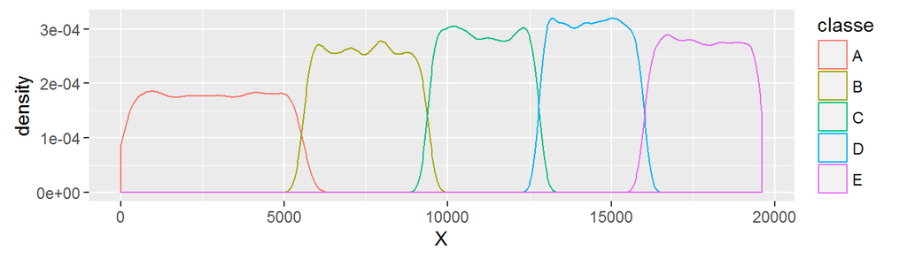

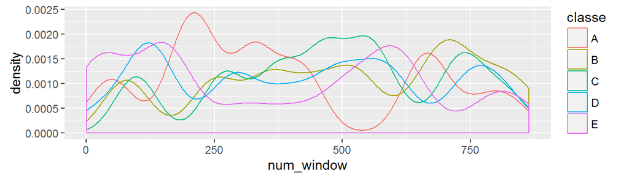

- logical:

As all logical are features full of NA’s there is not point in using those

```
##  kurtosis_yaw_belt skewness_yaw_belt kurtosis_yaw_dumbbell
##  Mode:logical      Mode:logical      Mode:logical
##  NA's:13737        NA's:13737        NA's:13737
##  skewness_yaw_dumbbell kurtosis_yaw_forearm skewness_yaw_forearm
##  Mode:logical          Mode:logical         Mode:logical
##  NA's:13737            NA's:13737           NA's:13737
```

- factors:

In factor vaiables we find 2 metada data features and the modeled variable:

```
##     user_name             cvtd_timestamp classe
##  adelmo  :2711   05/12/2011 11:24:1049   A:3906
##  carlitos:2196   28/11/2011 14:14:1030   B:2658
##  charles :2494   05/12/2011 11:25:1013   C:2396
##  eurico  :2131   30/11/2011 17:11:1003   D:2252
##  jeremy  :2334   05/12/2011 14:23: 986   E:2525
##  pedro   :1871   02/12/2011 14:57: 973
##                  (Other)         :7683
```

all thre of them are to be exluded. As for the rest of the variables we find they were assigned factor status due to small amount of levels. Also they are all numeric with significant amount of NAs which is an unwanted aspect excluding the whole factor set from the analysis.

## Modeling

1. rpart - tree model

```r
model_rpart <- train(data = DataForModeling, classe ~ . , method = "rpart")
```

2. rf - random forest

```r
model_randomForest <- train(data = DataForModeling, classe ~ . , method = "rf", prox = TRUE)
```

3. treebag - bagging for trees

```r
model_treebag <- train(data = DataForModeling, classe ~ . , method = "treebag")
```

4. lda - linear discriminatory analysis

```r
model_LDA <- train(data = DataForModeling, classe ~ . , method = "lda")
```

5. nb - naive bayes

```r
model_naivebaise <- train(data = DataForModeling, classe ~ . , method = "nb")
```

6. gbm - boosted trees

```r
model_BoostingTrees <- train(data = DataForModeling, classe ~ . , method = "gbm", verbose = FALSE)
```

In all models for training purposes I left the standard (bootstrap) cross validation for calibrating models.

```
##    Accuracy     Kappa    ModelName
## 1 0.4911441 0.3380370        rpart
## 2 0.9881018 0.9849466 randomForest
## 3 0.9731866 0.9660774      treebag
## 4 0.7015877 0.6224134          LDA
## 5 0.5096683 0.3927240   NaiveBayse
## 6 0.7552027 0.6895430 BoostedTrees
```

Now we crossvalidate our models with the Testing sample we left aside which will also provide estimate of out of sample error:

```
##    Accuracy     Kappa    ModelName
## 1 0.9976211 0.9969907 randomForest
## 2 0.9949023 0.9935518      treebag
```

To take a deeper look into how good were the preditions we can see how many and wat kind of wrong predictions happend in the dataset:

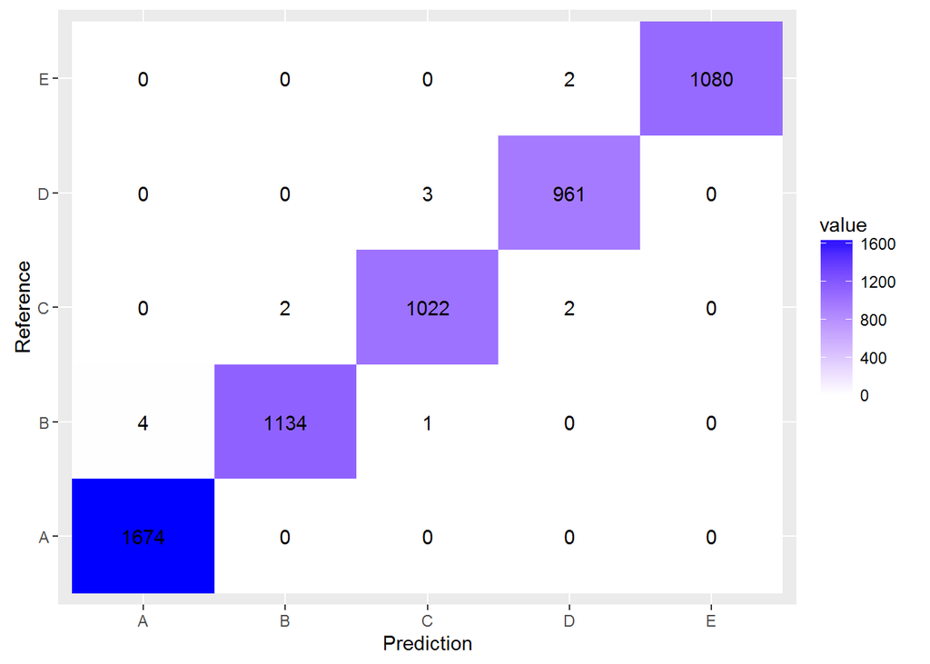

# Conclusions

There were two models that were significantly better than others:

1. random forest
2. bagging for trees

Out of which by a slim margin random forest provided better predictions on both training and test datasets minimizing errors (both in and out of sample).

# Citation

The data set used was made available bythe courtosy of:

Velloso, E.; Bulling, A.; Gellersen, H.; Ugulino, W.; Fuks, H. Qualitative Activity Recognition of Weight Lifting Exercises. Proceedings of 4th International Conference in Cooperation with SIGCHI (Augmented Human ’13) . Stuttgart, Germany: ACM SIGCHI, 2013.

Read more: http://groupware.les.inf.puc-rio.br/har#wle_paper_section#ixzz4UR9VIZ1I